# pre-final

Abhilash, Kritika, Priyanka, Shivani

11 August 2019

## Motivation

- Tinnitus is a highly common health problem which severely affects people. As a Tinnitus patient, people need to fill many questionnaires which can be tiring.
- If we know the possible sub categories of Tinnitus it would help medical practitioners to provide category specific medical assistance to the patients.
- Understanding the sub categories would also help to identify questionnaires which are only relevant to these sub categories and thus reduce the number questions patients might have to fill.

## Problem Statement

1. To identify relevant sub-categories of Tinnitus condition
2. To represent/describe the identified clusters and assign most relevant questionnaires respectively.

## Organisation

The project is organised as follows:

- Data preprocessing
- Global Clustering
- Subspace Clustering
- Evaluation

Let us first load all necessary libraries for this project

## Data preprocessing

Now we will step by step do the preprocessing of given data

```r
df <- read_rds("190426_charite_tinnitus.rds") %>%
  arrange(.testdatum) %>%
  group_by(.jour_nr) %>%
  slice(1) %>%
  ungroup() %>%
  filter(.phase == "A") %>%
  mutate(phqk_paniksyndrom = if_else(phqk_phqk_2a +
                                       phqk_phqk_2b +
                                       phqk_phqk_2c +
                                       phqk_phqk_2d +
                                       phqk_phqk_2e == 5, 1, 0)) %>%
  select(.jour_nr,
         .age,
         acsa_acsa,
         adsl_adsl_sum,
         bi_erschoepfung, bi_magen, bi_glieder, bi_herz, bi_beschwerden,
         bsf_geh, bsf_eng, bsf_aerg, bsf_an_de, bsf_mued, bsf_tnl,
         isr_deprsyn, isr_angstsyn, isr_zwasyn, isr_somasyn, isr_essstsyn,
         isr_zusatz, isr_isr_ges,
         phqk_depressivitaet, phqk_paniksyndrom,
         psq_anford, psq_anspan, psq_freude, psq_sorgen, psq_psq_sum,
         schmerzskal_beein10, schmerzskal_haeuf10, schmerzskal_staerke10,
         ses_ses_affektiv, ses_ses_sensorisch,
         sf8_bp_sf36ks, sf8_gh_sf36ag, sf8_mcs8, sf8_mh_sf36pw, sf8_pcs8,
         sf8_pf_sf36kf, sf8_re_sf36er, sf8_rp_sf36kr, sf8_sf_sf36sf, sf8_vt_sf36vit,
         sozk_soz01_male, sozk_soz02_german, sozk_soz05_partner, sozk_soz06_married,
         sozk_soz09_abitur, sozk_soz10_keinAbschl, sozk_soz11_job, sozk_soz18_selbstst,
         sozk_soz1920_krank, sozk_soz21_tindauer, sozk_soz2224_psycho, sozk_soz25_numdoc,
         swop_sw, swop_opt, swop_pes,
         tq_aku, tq_co, tq_em, tq_inti, tq_pb, tq_sl, tq_som, tq_tf,
         tinskal_beein10, tinskal_haeuf10, tinskal_laut10,
         starts_with("tlq"), -tlq_timestamp
  ) %>%
  drop_na()
originaldf <- read_rds("190426_charite_tinnitus.rds")
```

Now lets remove ‘journ.no’ as it is an identifier and will not be useful for analysis.

```r
df_allF <- select(df,-c(.jour_nr))

#Data frame with all features "Scaled" except journ no
df_allF_scaled<-scale(df_allF)%>%data.frame()
```

We will find out the co related columns in the data and drop them

```r
correlated_coloumns <- data.frame(F1 = character(),F2 = character(),coef = numeric())

#cat("\ncorrelation with 90%:\n")
matriz_cor <- cor(df_allF,method = "spearman")

for (i in 1:nrow(matriz_cor)){
  correlations <-  which((abs(matriz_cor[i,]) > 0.9) & (matriz_cor[i,] != 1))
  matriz_cor[correlations,i] <- NA

  if(length(correlations)> 0){
    #lapply(correlations,FUN =  function(x) (cat("\t",paste(colnames(test)[i], "with",colnames(test)[x]), "\n")))
    correlated_coloumns <-  rbind(correlated_coloumns,data.frame(F1=colnames(df_allF)[i],F2=colnames(df_allF)[correlations],coef=matriz_cor[i,correlations]))
    rownames(correlated_coloumns) <- NULL
  }
}

#No correlated columns

#dropping the columns
df_noCorr <- select(df_allF,-c("sf8_mh_sf36pw","tq_tf","tq_em","tq_co"))

#Data frame with reduced features "Scaled"
df_noCorr_scaled <- scale(df_noCorr)%>%data.frame()
```

## Elbow Method

Elbow method for getting optimal value of k. The idea behind elbow method is to to define number of clusters such that the total within-cluster sum of square (WSS) is minimized. The value of chosen k is such that adding another cluster does not affect the overall wss much.

```r
set.seed(123)
# Elbow method to get best k from k = 2 to k = 12.
k.max <- 12
rownames( df_noCorr_scaled ) <- seq_len( nrow( df_noCorr_scaled ) )
wss <- sapply(1:k.max,
              function(k){kmeans(df_noCorr_scaled, k, nstart=50,iter.max = 15 )$tot.withinss})
wss
```

```
##  [1] 75117.00 60395.52 56492.37 54795.04 53444.57 52488.47 51621.50
##  [8] 50844.91 50172.26 49531.40 49065.64 48413.36
```

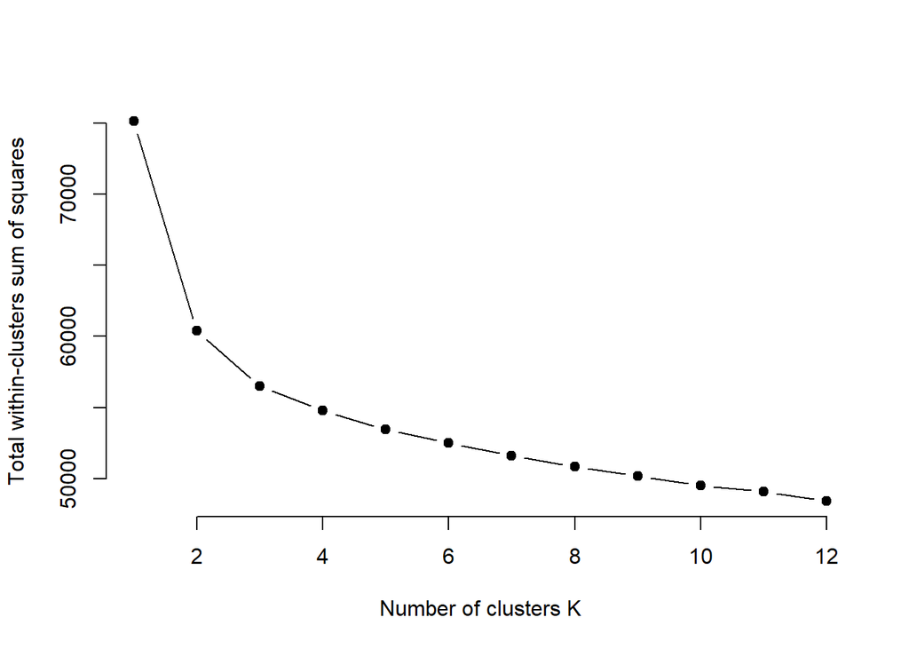

```r
plot(1:k.max, wss,
     type="b", pch = 19, frame = FALSE,
     xlab="Number of clusters K",
     ylab="Total within-clusters sum of squares")
```

## Bootstrap Sampling

Create different samples (with replacement) of data from the original dataset. With varying data (different samples), we will can check if the clustering results are stable or not. So we are plotting a Box-plot for each values of K against “Total within sum of square errors (totwss)”. We need to check if the result follows the same trend as the original elbow method does, or there is a significant change in the plot.

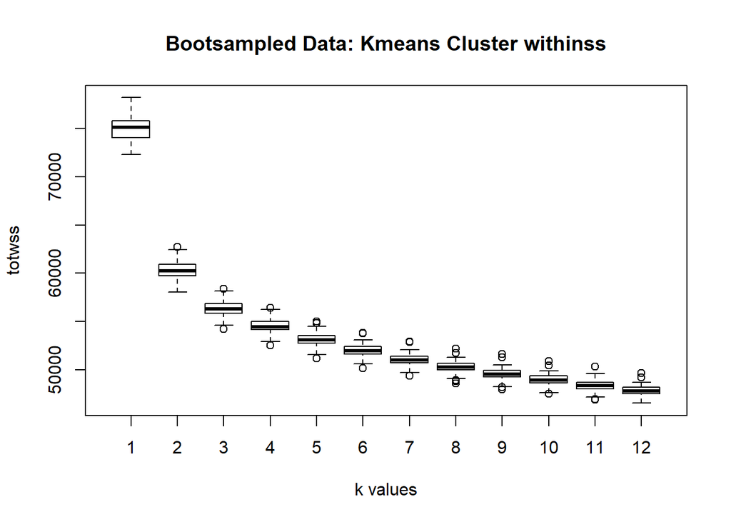

```r
#No. of Bootsamples to be created
bootsamplesize <- seq(1:100)

max_k <-seq(1:12)
wss.boot <- data.frame()

set.seed(123)
for(i in bootsamplesize){

  #Create Index with replacement
  index <- sample(1:nrow(df_noCorr_scaled),nrow(df_noCorr_scaled),replace = T)

  #create samples from the index
  dfSample <-  df_noCorr_scaled[index,]

  #run for each value of k for the current sample
  for(k in max_k){

    kmclust <- kmeans(dfSample,k,nstart=50,iter.max = 25)

    #Store the data (1 row) of current K and withinss in the dataframe
    wss.boot <- rbind(wss.boot, c(k,kmclust$tot.withinss))

  }
}

colnames(wss.boot) <- c('k','totwss')


#Plot the Data
boxplot(totwss~k, data = wss.boot, xlab = "k values", ylab = "totwss", main = "Bootsampled Data: Kmeans Cluster withinss")
```

## Hierarchical clustering

Hierarchical clustering can be done in two ways : 1) Top Down : Start with the entire data as a cluster and break them down until each point is a cluster in itself. 2) Bottom up : Start from individual points as clusters and merge them based on similarities until one cluster if formed.

There are different ways to calculate the distance/ similarity between individual points and in between the clusters which can be a very important factor in deciding the final cluster results.

So we first create a list of these methods and then create clusters for each combination.

Then we can calculate the clusters. The ac value of each cluster gives the quality/ tightness of each cluster. The closer the value is to 1 the better are the results.

**the agglomerative coefficient, measuring the clustering structure of the dataset.

For each observation i, denote by m(i) its dissimilarity to the first cluster it is merged with, divided by the dissimilarity of the merger in the final step of the algorithm. The ac is the average of all 1 - m(i). It can also be seen as the average width (or the percentage filled) of the banner plot. Because ac grows with the number of observations, this measure should not be used to compare datasets of very different sizes.**

```r
set.seed(123)
# methods to assess inter cluster similarity
m <- c( "average", "single", "complete", "ward")
names(m) <- c( "average", "single", "complete", "ward")

#distance measures
dist_methods <- c("euclidean","manhattan","maximum", "canberra","binary","minkowski")
names(dist_methods)<- c("euclidean","manhattan","maximum", "canberra","binary","minkowski")

# function to compute coefficient
final_dist_m<-list()
final_m<-list()
for(dist_m in dist_methods)
{
  dist_matrix<-dist(df_noCorr_scaled, method = dist_m)
  for(x in m)
  {
    hc <-agnes(dist_matrix, method = x)
    ac<-hc$ac
    title<-sprintf("Distance: %s,Inter cluster Distance: %s, ac value: %f",dist_m,x,ac)
    pltree(hc, cex = 0.6, hang = -1,main = title)
    if(!is.nan(ac) && ac>0.95)
    {
      print(title)
      final_dist_m<-c(final_dist_m,dist_m)
      final_m<-c(final_m,x)
    }
  }
}
```

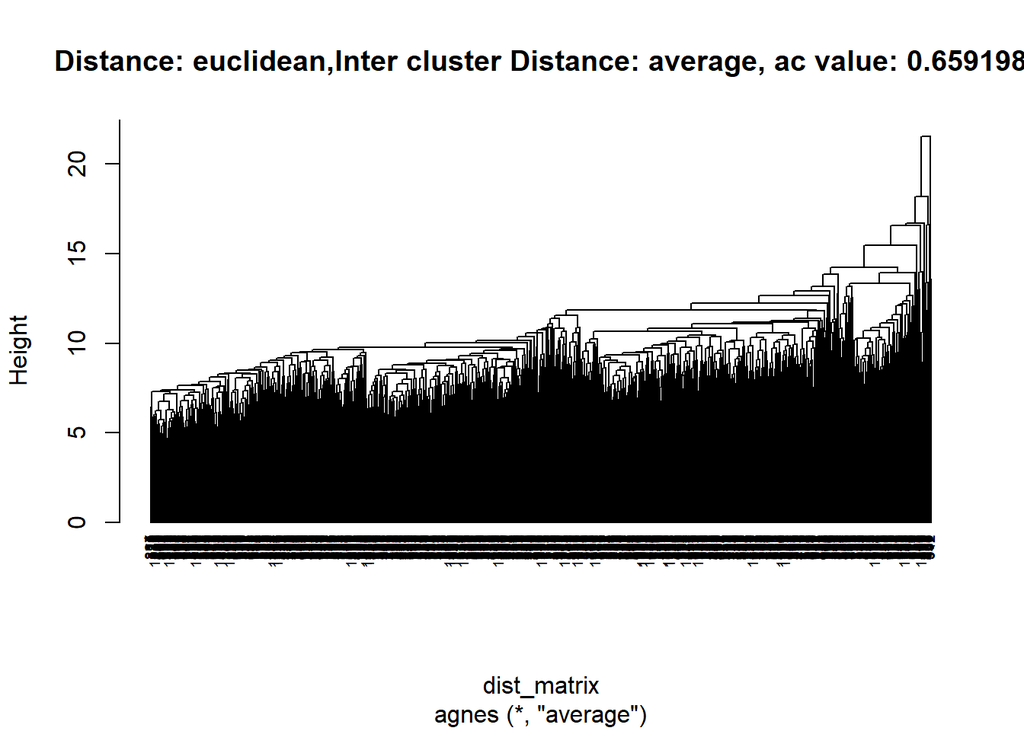

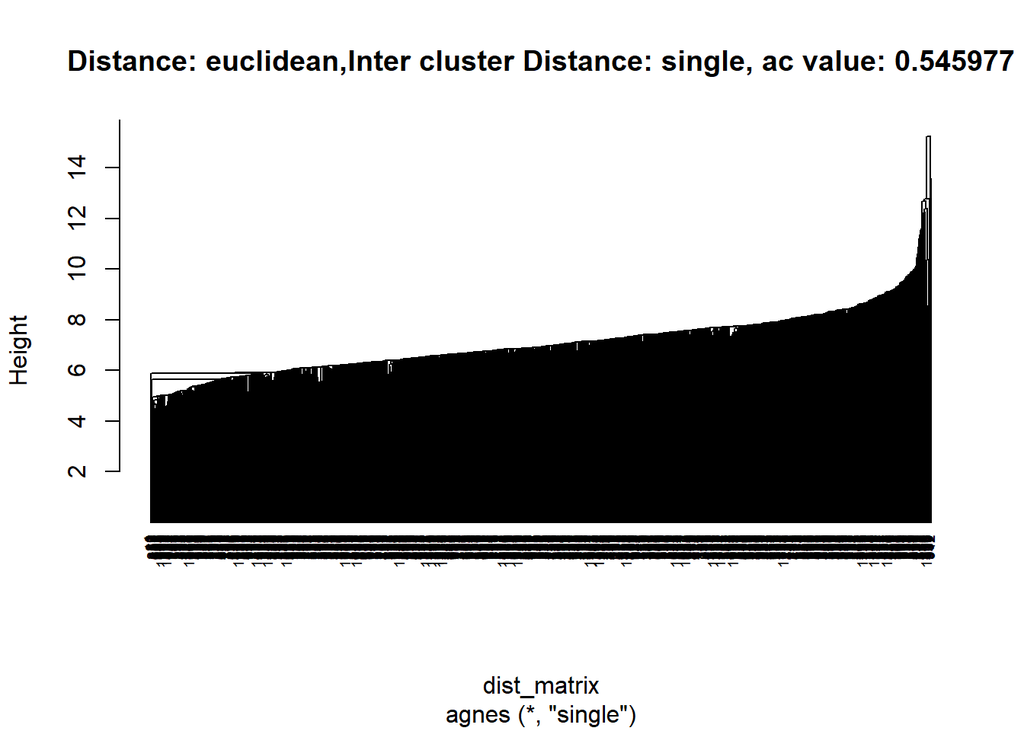

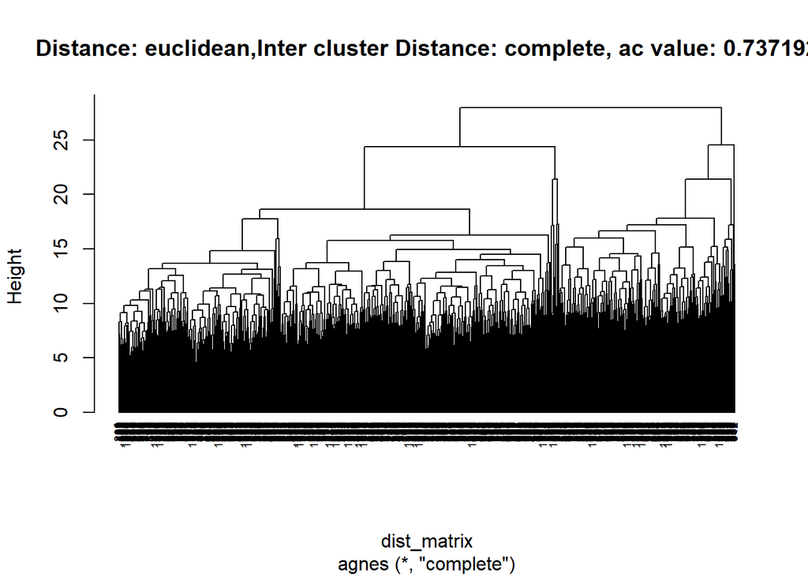

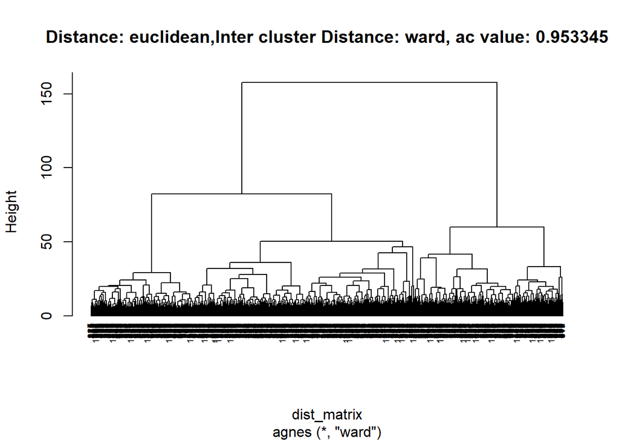

```
## [1] "Distance: euclidean,Inter cluster Distance: ward, ac value: 0.953345"
```

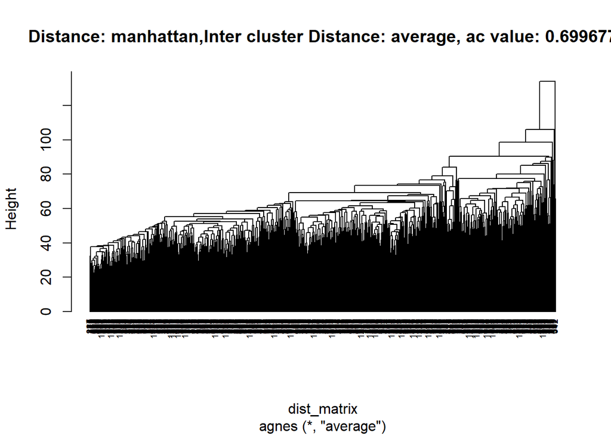

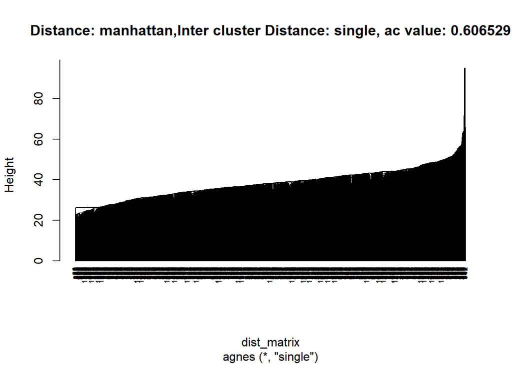

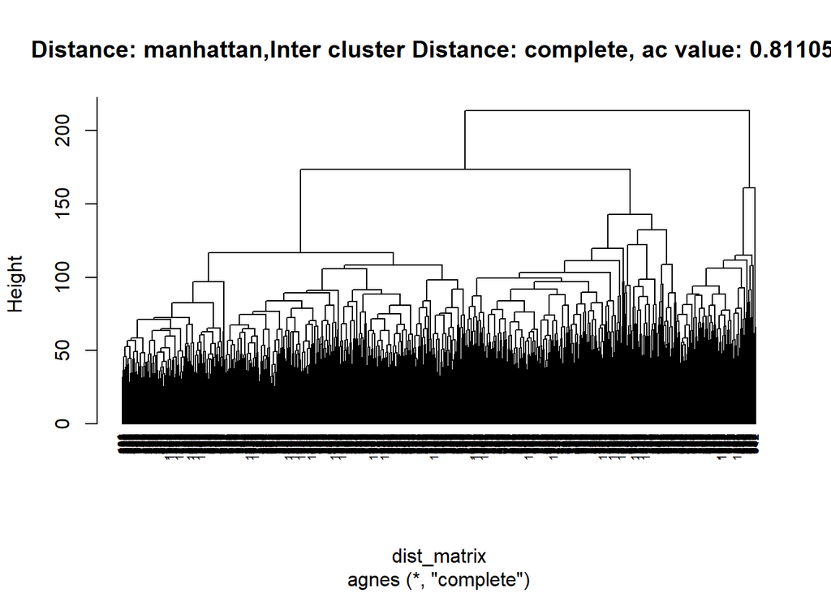

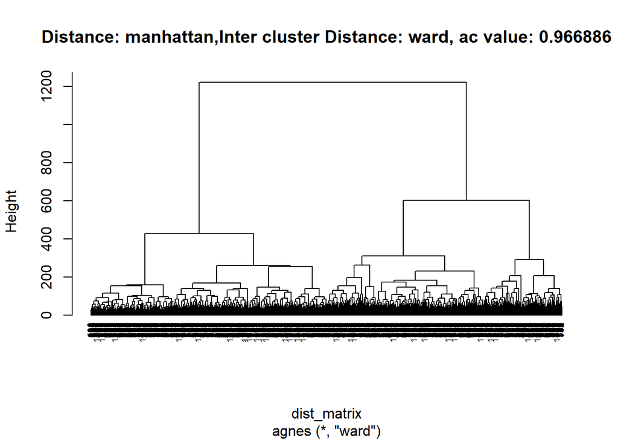

```
## [1] "Distance: manhattan,Inter cluster Distance: ward, ac value: 0.966886"
```

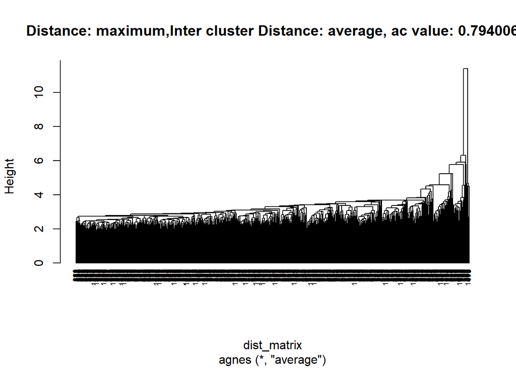

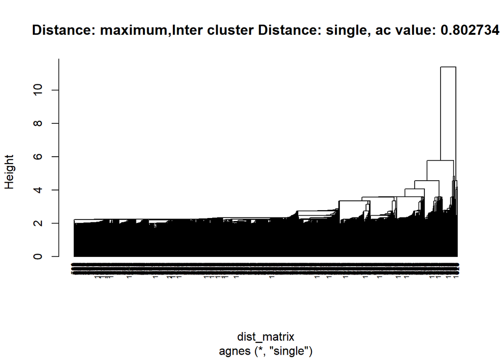

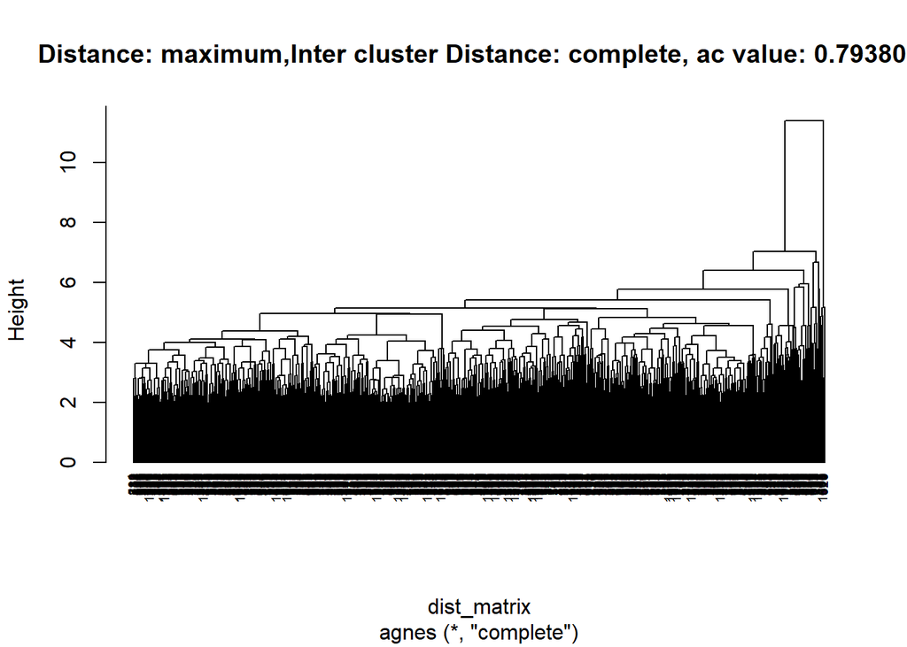

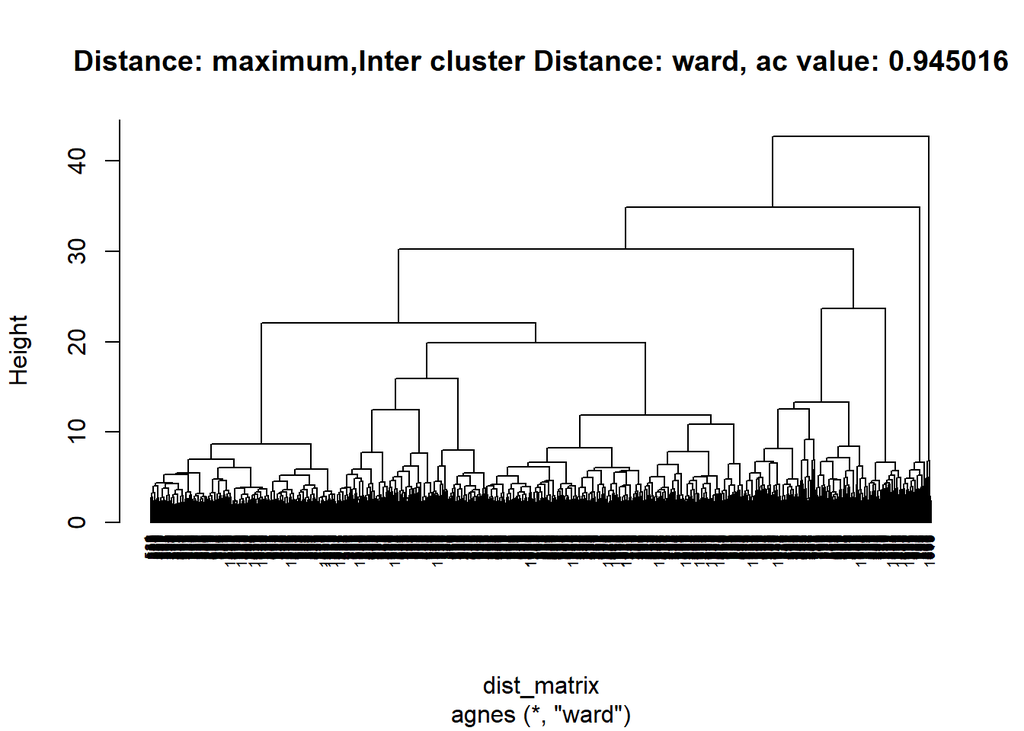

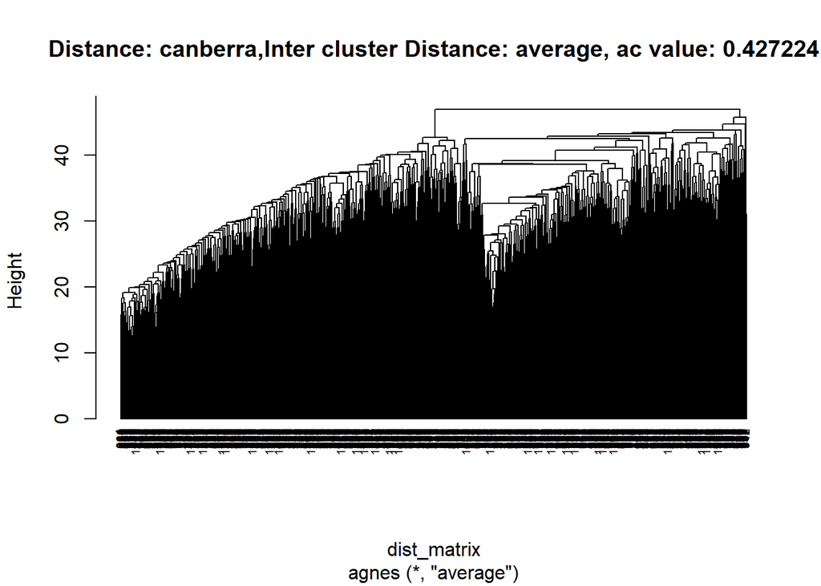

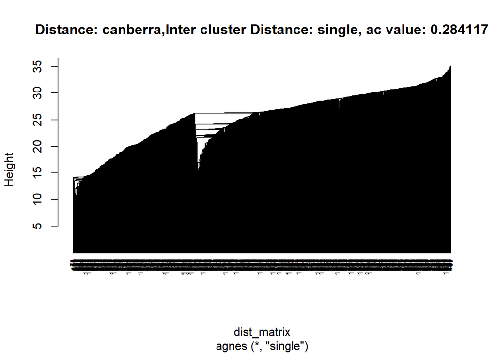

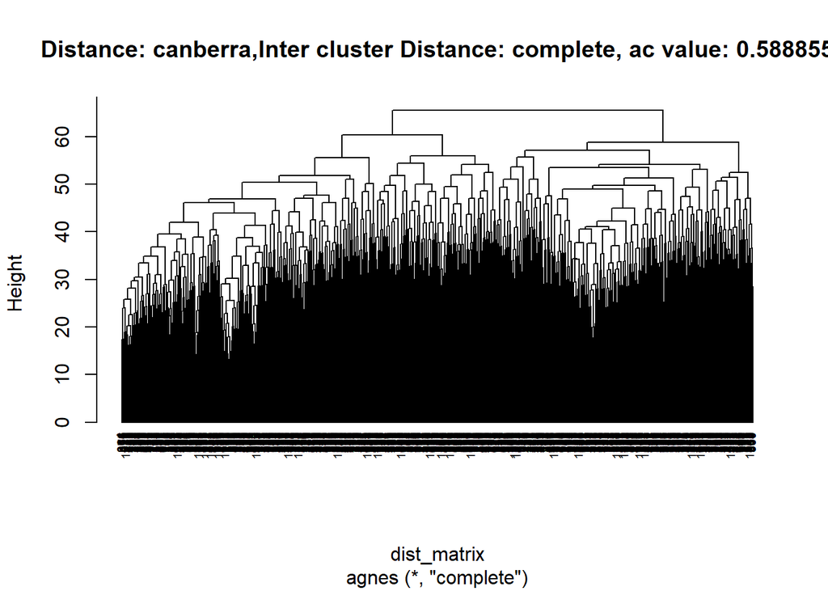

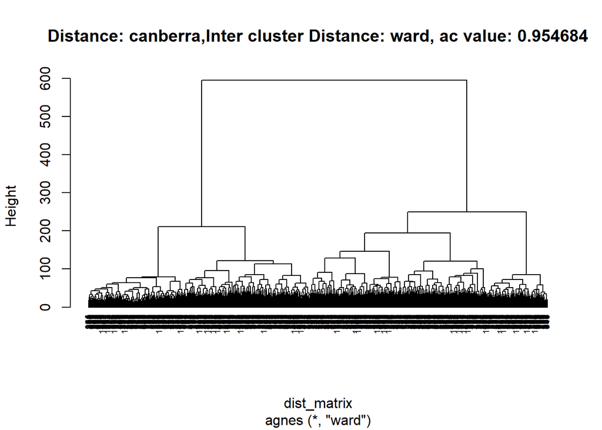

```
## [1] "Distance: canberra,Inter cluster Distance: ward, ac value: 0.954684"
```

[figure not shown]

[figure not shown]

[figure not shown]

[figure not shown]

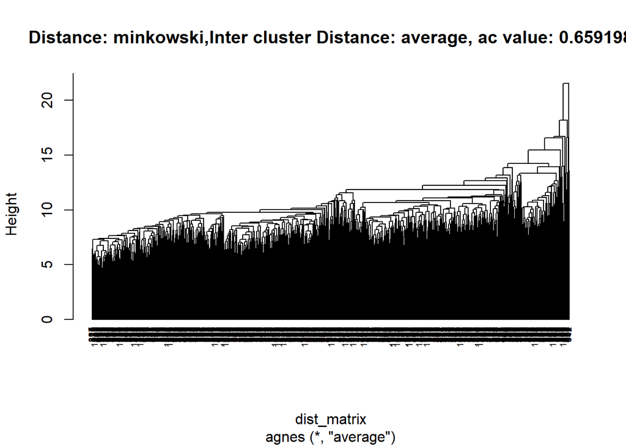

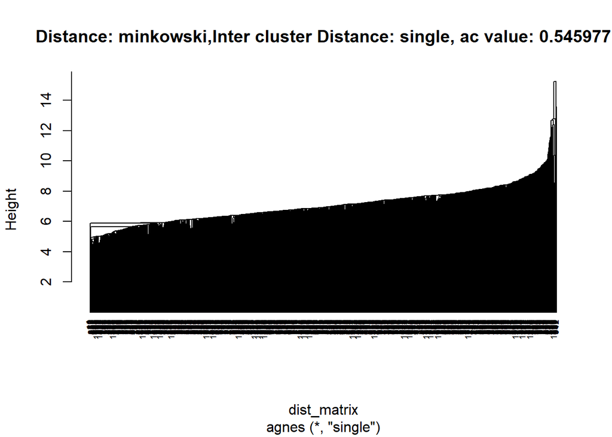

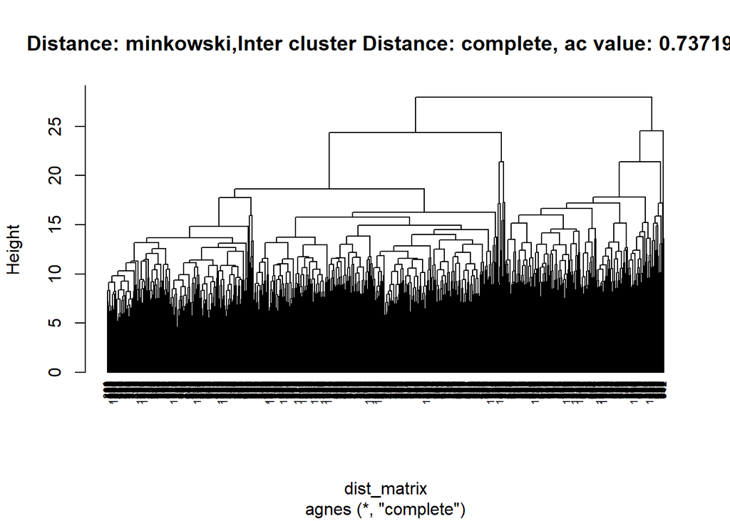

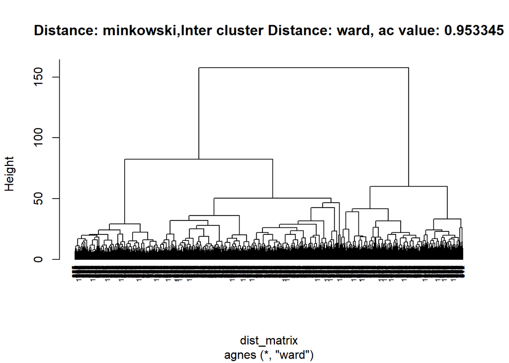

```
## [1] "Distance: minkowski,Inter cluster Distance: ward, ac value: 0.953345"
```

```r
#Now we can choose the desired combination, for example: Euclidean and Ward method and then we can cut the tree to get the final clusters.

dist_matrix<-dist(df_noCorr_scaled, method = "euclidean")
hc <-agnes(dist_matrix, method = "ward")
```

## PCA-Kmeans

Prinicipal Component Analysis is used for High Dimensional Dataset to convert the possibly correlated features into linearly uncorrelated variables called Principal Components (PCs). The first Principal Component (PC) explains the most amount of variance in the data. The PCs are arranged in the decreasing order of variance explained. This can be seen in Scree Plots. To explain certain amount of variance of the data, we need to choose the subsequent amount of the PC number. This can be done using the help of the Score Plots. After selecting first n PCs, we need to save that in another dataframe and then we can perform our clustering algorithm on the new transformed data.

```r
#Create Prinicipal Components
km.pc <- prcomp(df_noCorr_scaled, center = TRUE)
summary(km.pc)
```

```
## Importance of components:
##                           PC1     PC2     PC3     PC4     PC5    PC6
## Standard deviation     4.6230 2.00093 1.74959 1.54854 1.44139 1.4012
## Proportion of Variance 0.2928 0.05485 0.04193 0.03285 0.02846 0.0269
## Cumulative Proportion  0.2928 0.34761 0.38955 0.42240 0.45086 0.4778
##                           PC7     PC8     PC9    PC10    PC11    PC12
## Standard deviation     1.2987 1.27930 1.22575 1.19983 1.18766 1.14996
## Proportion of Variance 0.0231 0.02242 0.02058 0.01972 0.01932 0.01812
## Cumulative Proportion  0.5009 0.52328 0.54386 0.56358 0.58290 0.60102
##                           PC13    PC14    PC15    PC16    PC17    PC18
## Standard deviation     1.12606 1.10687 1.08900 1.06914 1.05859 1.03722
## Proportion of Variance 0.01737 0.01678 0.01625 0.01566 0.01535 0.01474
## Cumulative Proportion  0.61839 0.63517 0.65142 0.66707 0.68243 0.69716
##                           PC19    PC20    PC21    PC22    PC23    PC24
## Standard deviation     1.00231 0.99391 0.98505 0.92717 0.92282 0.92161
## Proportion of Variance 0.01376 0.01353 0.01329 0.01178 0.01167 0.01164
## Cumulative Proportion  0.71092 0.72446 0.73775 0.74952 0.76119 0.77283
##                           PC25    PC26    PC27    PC28    PC29    PC30
## Standard deviation     0.89841 0.88230 0.85757 0.84194 0.82976 0.81116
## Proportion of Variance 0.01106 0.01066 0.01007 0.00971 0.00943 0.00901
## Cumulative Proportion  0.78388 0.79455 0.80462 0.81433 0.82376 0.83278
##                           PC31    PC32    PC33    PC34   PC35    PC36
## Standard deviation     0.79787 0.79096 0.75432 0.74674 0.7351 0.72160
## Proportion of Variance 0.00872 0.00857 0.00779 0.00764 0.0074 0.00713
## Cumulative Proportion  0.84150 0.85007 0.85786 0.86550 0.8729 0.88003
##                           PC37    PC38    PC39    PC40    PC41    PC42
## Standard deviation     0.71025 0.69192 0.66216 0.64913 0.64206 0.63437
## Proportion of Variance 0.00691 0.00656 0.00601 0.00577 0.00565 0.00551
## Cumulative Proportion  0.88695 0.89350 0.89951 0.90528 0.91093 0.91644
##                           PC43    PC44    PC45   PC46    PC47    PC48
## Standard deviation     0.62138 0.61500 0.60203 0.5918 0.57476 0.56539
## Proportion of Variance 0.00529 0.00518 0.00496 0.0048 0.00453 0.00438
## Cumulative Proportion  0.92173 0.92691 0.93188 0.9367 0.94120 0.94558
##                           PC49    PC50    PC51    PC52    PC53    PC54
## Standard deviation     0.54769 0.54129 0.53132 0.52081 0.51710 0.50624
## Proportion of Variance 0.00411 0.00401 0.00387 0.00372 0.00366 0.00351
## Cumulative Proportion  0.94969 0.95370 0.95757 0.96129 0.96495 0.96846
##                           PC55    PC56    PC57    PC58    PC59    PC60
## Standard deviation     0.48600 0.46841 0.45390 0.44185 0.43036 0.42299
## Proportion of Variance 0.00324 0.00301 0.00282 0.00267 0.00254 0.00245
## Cumulative Proportion  0.97169 0.97470 0.97752 0.98020 0.98273 0.98519
##                           PC61    PC62    PC63   PC64    PC65    PC66
## Standard deviation     0.41433 0.39963 0.38963 0.3819 0.35023 0.33722
## Proportion of Variance 0.00235 0.00219 0.00208 0.0020 0.00168 0.00156
## Cumulative Proportion  0.98754 0.98972 0.99180 0.9938 0.99548 0.99704
##                           PC67    PC68    PC69    PC70     PC71      PC72
## Standard deviation     0.32402 0.29826 0.12711 0.07698 0.004119 2.435e-07
## Proportion of Variance 0.00144 0.00122 0.00022 0.00008 0.000000 0.000e+00
## Cumulative Proportion  0.99848 0.99970 0.99992 1.00000 1.000000 1.000e+00
##                             PC73
## Standard deviation     2.053e-15
## Proportion of Variance 0.000e+00
## Cumulative Proportion  1.000e+00
```

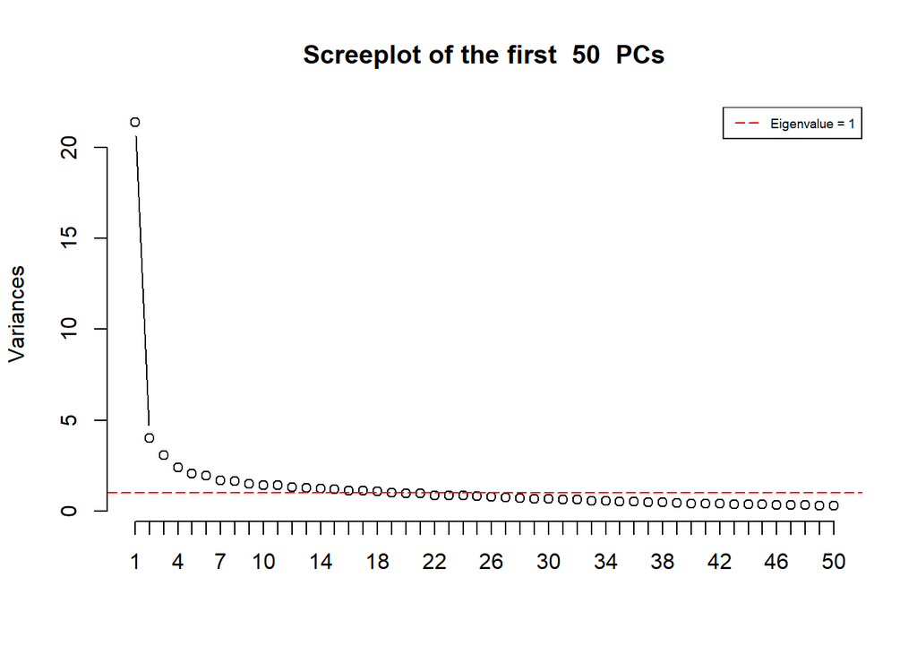

```r
#Maxmimum PC for Scree and Score Plots for visualization
maxPC <- 50

screeplot(km.pc, type = "l", npcs = maxPC, main = paste("Screeplot of the first ", maxPC," PCs"))

#eigenvalues <1 would mean that the component actually explains less than a single explanatory variable
abline(h = 1, col="red", lty=5)
legend("topright", legend=c("Eigenvalue = 1"),
       col=c("red"), lty=5, cex=0.6)
```

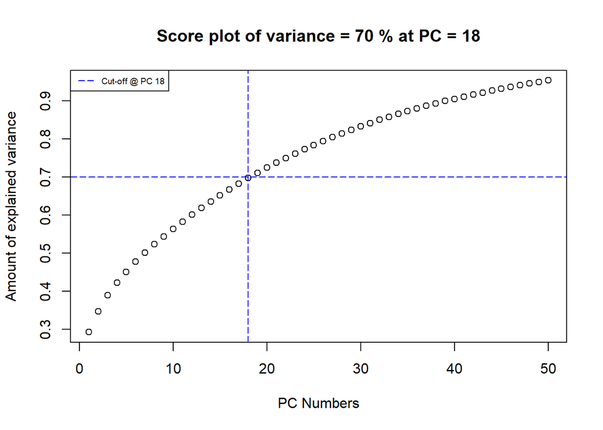

```r
#No.of PCs required to explain variance
PC_num <- 18
PC_var <- 0.70

cumpro <- cumsum(km.pc$sdev^2 / sum(km.pc$sdev^2))
plot(cumpro[0:maxPC], xlab = "PC Numbers", ylab = "Amount of explained variance", main = paste("Score plot of variance =", PC_var*100, "% at PC =",PC_num))


abline(v = PC_num, col="blue", lty=5)
abline(h = PC_var, col="blue", lty=5)

legend("topleft", legend=c(paste("Cut-off @ PC",PC_num)), col=c("blue"), lty=5, cex=0.6)
```

```r
#Creating dataset with first PC_num PCs that we need to explain variance
df_PC <- km.pc$x[,1:PC_num]
```

## ORCLUS

To perform subspace clustering where the clusters are concentrated in different cluster specific subspaces of the data.

Orclus is done with respect to 3 steps: 1) Assign : The database is partitioned into k0 current clusters by assigning each point to its closest seed. In the process of partitioning, the distance of a database point to seed is measured in the subspace. At the end of this procedure each seed is replaced by the centroid of the cluster which was just created. 2) FindVectors : This is to find the subspace of dimensionality l for each current cluster. 3) Merge: During a given iteration, the Merge phase reduces the number of clusters from k0 to k.

The quality of the clustering can be measured by the sparsity coefficient and within.proj parametes of cluster results. The within projection parameter give the sse of each cluster. According to these values we have to select the cluster in lower dimenstion.

```r
#Represents the tuning of clusters according to quality measures

# for (k in seq(10,30,by = 5)) {
#
#   for (i in seq(20,60,by = 5)) {
#
#     orclus_res_k2 <- orclus(x = subspace_data,k=2,l = i, k0 = k)
#     tune_lf_sparsity[j,1] <- k
#     tune_lf_sparsity[j,2] <- i
#     tune_lf_sparsity[j,3] <- orclus_res_k2$sparsity.coefficient
#     tune_lf_sparsity[j,4] <- sum(orclus_res_k2$within.projens)
#     j <- j+1
#   }
# }

k4_tuning_dataset <- read_csv("inital_tune_l_sparsity.csv")
```

##PROCLUS

Projected subspace Clustering is a method with uses Kmediods to cluster the high dimensional data. It uses greedy method to find a set of medioods that represents the cluster. These mediods are iteratively selected until we get perfect set of mediods with cardinality d0. The dimensions of each cluster can differ, which means it only selects the dimension the represents that particular cluster.In iterative phase, the quality of clusters are also refined before the final results. Proclus is robust to outlier.

```r
#For K = 2
ProClus_clusters_k2<- ProClus(df_noCorr_scaled,k=2,d=70)
#Getting each cluster elements
k2_cluster1<-ProClus_clusters_k2[[1]]$objects
k2_cluster2<-ProClus_clusters_k2[[2]]$objects

# For K = 4
ProClus_clusters_k4<- ProClus(df_noCorr_scaled,k=4,d=70)
#Getting each cluster elements
k4_cluster1<-ProClus_clusters_k4[[1]]$objects
k4_cluster2<-ProClus_clusters_k4[[2]]$objects
k4_cluster3<-ProClus_clusters_k4[[3]]$objects
k4_cluster4<-ProClus_clusters_k4[[4]]$objects
```

## Visualisation

Creating a summary data frame for capturing population mean

```r
feature_summary_scaled<-data.frame(df_allF_scaled%>%
                               summarise_each(mean))
feature_summary<-data.frame(df_allF%>%
                              summarise_each(mean))
```

For visluation of clustering results we choose a radial chart. To generate this radial chart we need format the data in a data structure suitable for plotting. The bar height is the scaled value of the features of a cluster. The tooltip gives extra information about the actual feature value and the population mean for the feature.

```r
#Finally creating a data frame which can be used for the visualization.
options(scipen = 999)
createPlotData<-function(algo_name,clus_name,cluster_scaled,cluster)
 { cluster_plot_data<-rbind(colnames(cluster[-1]),cluster_scaled[-1],feature_summary,cluster[-1])
  rownames(cluster_plot_data)<-c("feature","scaled_cluster_feature_value","population_mean","cluster_feature_value")
  cluster_plot_data<-t(cluster_plot_data)%>%data.frame()%>%mutate(algorithm=algo_name,cluster_name=clus_name)
  return(cluster_plot_data)
}


getPlotData<-function(algo_name,final_labels,no_of_clusters)
{
  # labelling the records
  df_allF_labeled<-df_allF%>%
  mutate(label = final_labels)
df_allF_scaled_labeled<-df_allF_scaled%>%
  mutate(label = final_labels)

# creating cluster feature vectors from obtained labels

cluster_features_scaled<-data.frame(df_allF_scaled_labeled%>%
                               group_by(label)%>%
                               summarise_each(mean))
cluster_features<-data.frame(df_allF_labeled%>%
                               group_by(label)%>%
                               summarise_each(mean))
  plotData<-list()
  for(i in seq(1:no_of_clusters))
  {
    clus_name<-paste("Type ",i)
    plotData[[i]]<-createPlotData(algo_name,clus_name,cluster_features_scaled[i,],cluster_features[i,])
  }
  return(plotData)
}
```

## Decision Tree

Now we have plotted all the feature values for each cluster. However for each cluster there are only a few features which clearly distinguish it from other clusters. To find out which features and their respective values are responsible to identify a cluster we can use supervised techniques. Let us now use a Decision Tree algorithm to identify which features are the most important to lead us to get our cluster labels as leaf nodes.

Now to get the decision tree as a classifier intead of a regressor we need to make the predicting variable as non numeric.

```r
createDT<-function(final_labels,remove_na)
{
  set.seed(123)

  # labelling the records
  df_allF_labeled<-df_allF%>%
  mutate(label = final_labels)
  df_string_labeled<-df_allF_labeled

  #Adding "Type" to each cluster number to make it non numeric
  df_string_labeled$label<-sub("^","Type ",df_allF_labeled$label)
  if(remove_na)
  {
    df_string_labeled <- df_string_labeled[-c(which(is.na(df_string_labeled$label))),]
  }

  trctrl <- trainControl(method = "boot", number = 10)
  dtree_fit <- train(label ~., data = df_string_labeled, method = "rpart",
                     parms = list(split = "information"),
                     trControl=trctrl,
                     tuneLength = 10)

  prp(dtree_fit$finalModel, box.palette = "Reds", tweak = 1.2)
}
```

## Random Forest

```r
set.seed(123)
##Tune random forest
tuneRandomForest<-function(labels){
# labelling the records
data<-df_allF%>%
  mutate(label = labels)
data$label<- as.factor(data$label)
x <- data[,1:77]
y <- data[,78]
#tuning of rf
customRF <- list(type = "Classification", library = "randomForest", loop = NULL)
customRF$parameters <- data.frame(parameter = c("mtry", "ntree"), class = rep("numeric", 2), label = c("mtry", "ntree"))
customRF$grid <- function(x, y, len = NULL, search = "grid") {}
customRF$fit <- function(x, y, wts, param, lev, last, weights, classProbs, ...) {
  randomForest(x, y, mtry = param$mtry, ntree=param$ntree, ...)
}
customRF$predict <- function(modelFit, newdata, preProc = NULL, submodels = NULL)
  predict(modelFit, newdata)
customRF$prob <- function(modelFit, newdata, preProc = NULL, submodels = NULL)
  predict(modelFit, newdata, type = "prob")
# train model
control <- trainControl(method="repeatedcv", number=5, repeats=2)
tunegrid <- expand.grid(.mtry=c(5:12), .ntree=c(500,1000, 1500))
set.seed(123)
custom <- train(label~., data=data, method=customRF,  tuneGrid=tunegrid, trControl=control)
#summary(custom)
plot(custom)
print(custom)
}

##applying random forest
applyrf<-function(labels,numClusters,ntree,mtry){
# labelling the records
data<-df_allF%>%
  mutate(label = labels)
data$label<- as.factor(data$label)
data.rf <- randomForest(formula= label ~ ., data=data, importance=TRUE,ntree=ntree,mtry=mtry,
                        proximity=TRUE)
print(data.rf)
plot(data.rf)
varImpPlot(data.rf)  #the first graph shows how worse the model will perfrom after removing each variable and second shows how pure the nodes are at the end of the tree
impfeat<-importance(data.rf)
impfeatdf<-data.frame(impfeat)
impfeatorder<-impfeatdf[order(-impfeatdf$MeanDecreaseAccuracy),]
if(numClusters==2)
  impfeatorder$X1<-impfeatorder$X2<-impfeatorder$MeanDecreaseGini<-NULL
if(numClusters==4)
  impfeatorder$X1<-impfeatorder$X2<-impfeatorder$X3<-impfeatorder$X4<-impfeatorder$MeanDecreaseGini<-NULL
print(impfeatorder)
}
```

## Note:

To be run after creating labels below. Used only once to Tune the model parameters for building Random Forest.

```r
##function call
# tuneRandomForest(hk2_labels)
# tuneRandomForest(km2_labels)
# tuneRandomForest(h2_labels)
# tuneRandomForest(pckm2_labels)
# tuneRandomForest(ok2_labels)
# tuneRandomForest(p2_labels)
# tuneRandomForest(hk4_labels)
# tuneRandomForest(km4_labels)
# tuneRandomForest(h4_labels)
# tuneRandomForest(pckm4_labels)
# tuneRandomForest(p4_labels)
# tuneRandomForest(ok4_labels)
```

## Performing Radial Chart Visualisation and Decision Tree for selected Cluster numbers

# Fetching labels for k=2

```r
set.seed(123)
removeNA <- 0 #Flag
num_clusters <- 2

# k means
set.seed(123)
kmclust2 <- kmeans(df_noCorr_scaled,num_clusters, nstart=50,iter.max = 15)
km2_labels <- kmclust2$cluster
cluster_plot_data<-getPlotData("K-means",km2_labels,num_clusters)
r2d3(data = cluster_plot_data[[1]], script = "cluster_chart.js",viewer ="internal")
```

[interactive chart not shown]

```r
r2d3(data = cluster_plot_data[[2]], script = "cluster_chart.js",viewer ="internal")
```

[interactive chart not shown]

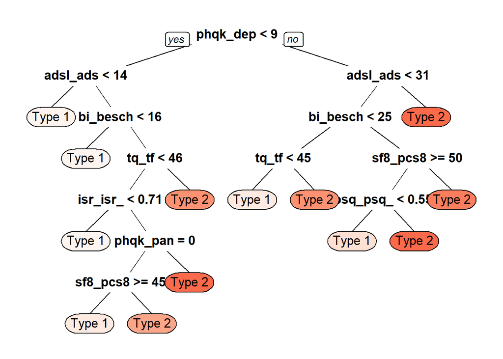

```r
createDT(km2_labels,removeNA)
```

```r
# applyrf(km2_labels,2,,)

# Hierarchical
set.seed(123)
h2_labels<-cutree(hc,k=num_clusters)
cluster_plot_data<-getPlotData("Hierarchical Clustering",h2_labels,num_clusters)
r2d3(data = cluster_plot_data[[1]], script = "cluster_chart.js",viewer ="internal")
```

[interactive chart not shown]

```r
r2d3(data = cluster_plot_data[[2]], script = "cluster_chart.js",viewer ="internal")
```

[interactive chart not shown]

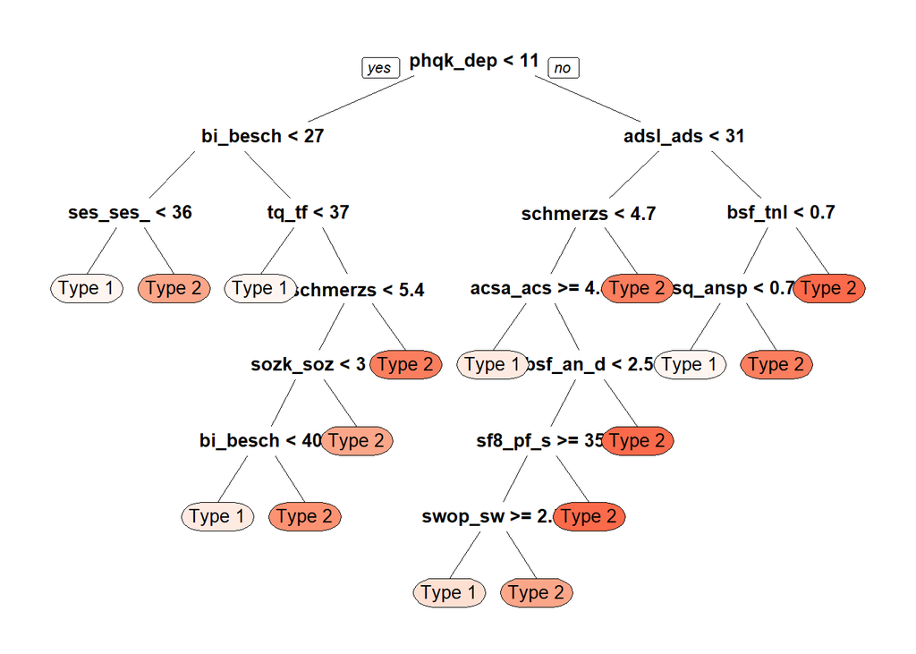

```r
createDT(h2_labels,removeNA)
```

```r
# applyrf(h2_labels,2,,)

#PCA- KMEANS
set.seed(123)
pckmclust2 <- kmeans(df_PC,num_clusters, nstart=50,iter.max = 15)
pckm2_labels <- pckmclust2$cluster
cluster_plot_data<-getPlotData("PCA K-means",pckm2_labels,num_clusters)
r2d3(data = cluster_plot_data[[1]], script = "cluster_chart.js",viewer ="internal")
```

[interactive chart not shown]

```r
r2d3(data = cluster_plot_data[[2]], script = "cluster_chart.js",viewer ="internal")
```

[interactive chart not shown]

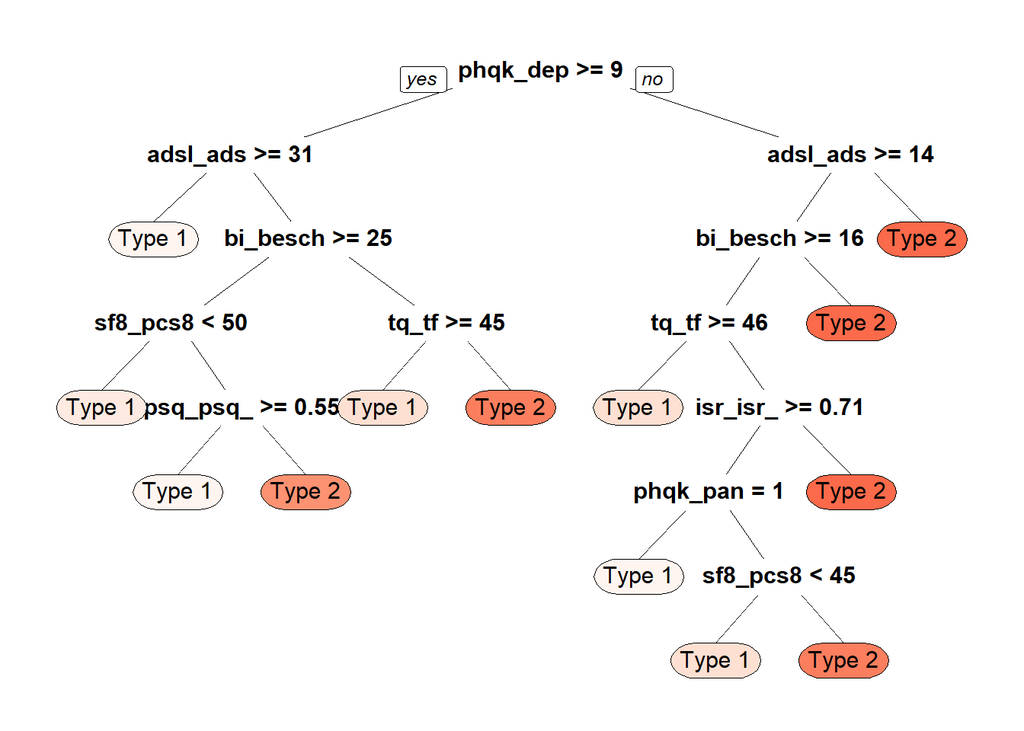

```r
createDT(pckm2_labels,removeNA)
```

```r
# applyrf(pckm2_labels,2,,)

# HK means
set.seed(123)
res.hk2 <-hkmeans(df_noCorr_scaled, num_clusters)
hk2_labels <- res.hk2$cluster
cluster_plot_data<-getPlotData("HK-means",hk2_labels,num_clusters)
r2d3(data = cluster_plot_data[[1]], script = "cluster_chart.js",viewer ="internal")
```

[interactive chart not shown]